# Внешний курс. Блок 2 - защита ПК/телефона

Основы информационной безопасности

Ефремова Полина Александровна

1132246726@rudn.ru

Российский университет дружбы народов

2026-05-16

# Информация

## Докладчик

- Ефремова Полина Александровна
- бакалавр
- Российский университет дружбы народов
- 1132246726@rudn.ru
- Доклад по теме: Внешний курс Stepik: “Основы кибербезопасности”

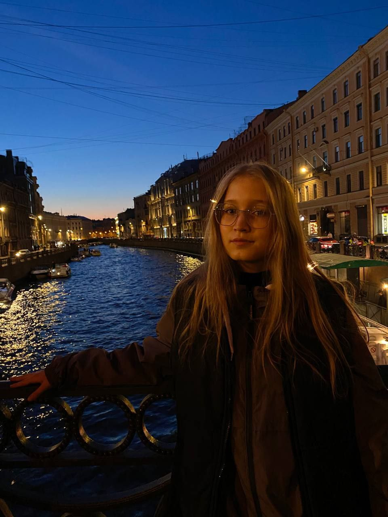

# Вводная часть

## Актуальность

- Рост количества вредоносного ПО
- Утечки паролей и персональных данных
- Необходимость защиты пользовательских устройчтв

## Объект и предмет исследования

### Объект исследования:

Безопасность пользовательских устройств

### Предмет исследования:

Методы защиты данных, паролей и программной среды

## Цели и задачи

Цель - изучение методов защиты пользовательских устройств и данных

Задачи:

- изучить методы шифрования дисков;
- рассмотреть принципы хранения паролей;
- исследовать CAPTCHA и защиту от перебора;
- изучить фишинг и вредоносное ПО

## Материалы и методы

Материалы:

- курс Stepik;
- примеры атак и защитных механизмов;
- тестовые задания

Методы:

- анализ угроз;
- изучение механизма защиты;
- сравнение методов аутентификации

# Основная часть: Выполнение заданий 2 блока

## Шифрование диска

Шифрование диска - технология защиты информации, переводящая данные на диске в нечитаемый код, который нелегальный пользователь не сможет легко расшифровать. Соответственно, можно.

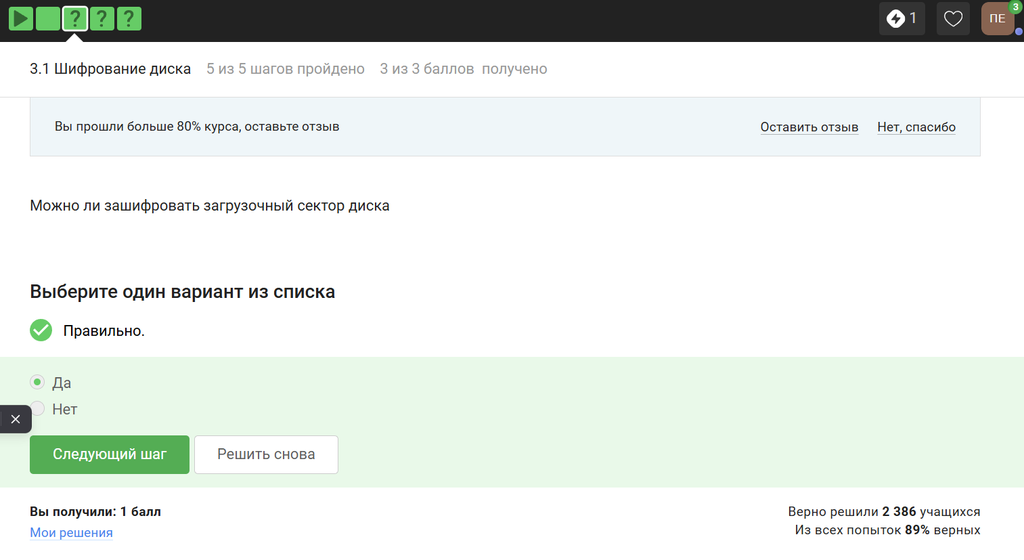

Рисунок 1: Вопрос 1

Ответ представлен на изображении.

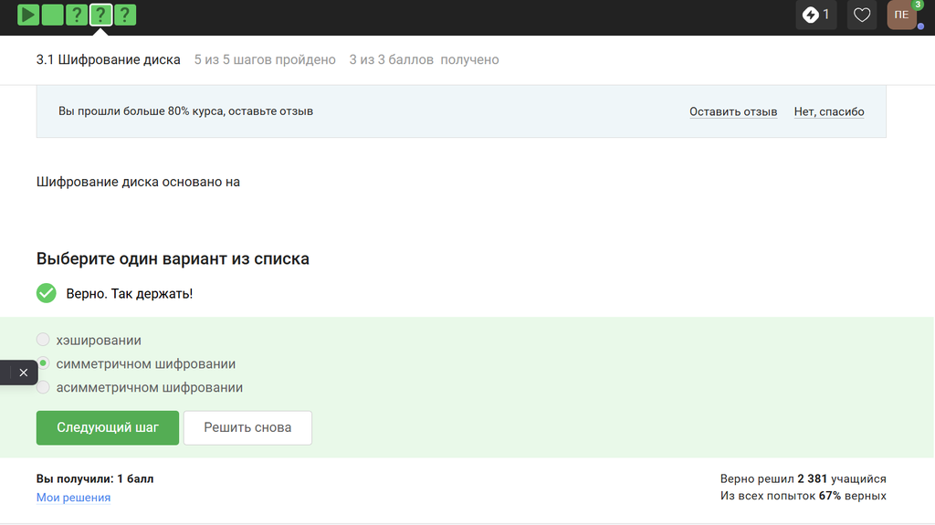

Рисунок 2: Вопрос 2

Отмечены программы, с помощью которых можно зашифровать жёсткий диск.

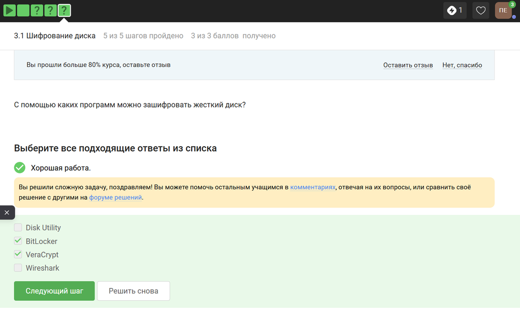

Рисунок 3: Вопрос 3

## Пароли

Стойкий пароль должен содержать строчные и заглавные буквы, цифры, а также специальные символы - и желательно это несвязный набор знаков, и точно не имя питомца или дата своего рождения.

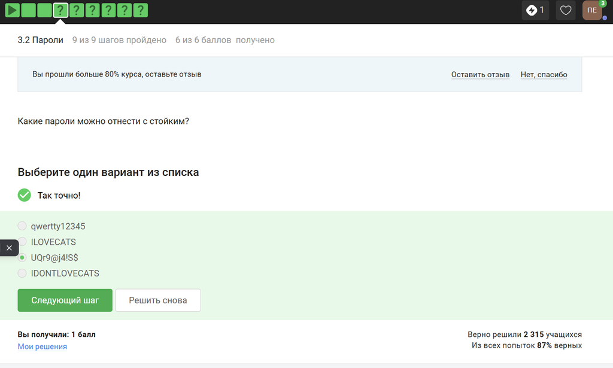

Рисунок 4: Вопрос 4

Все варианты кроме менеджера паролей совершенно ненадёжные.

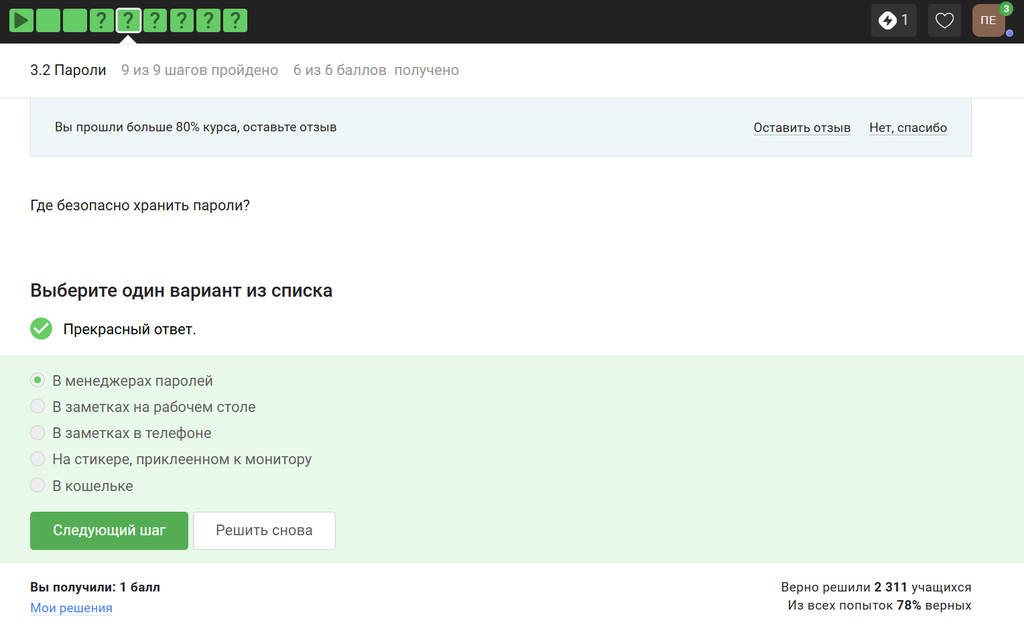

Рисунок 5: Вопрос 5

Капча нужна для проверки того, что за экраном не робот, а человек.

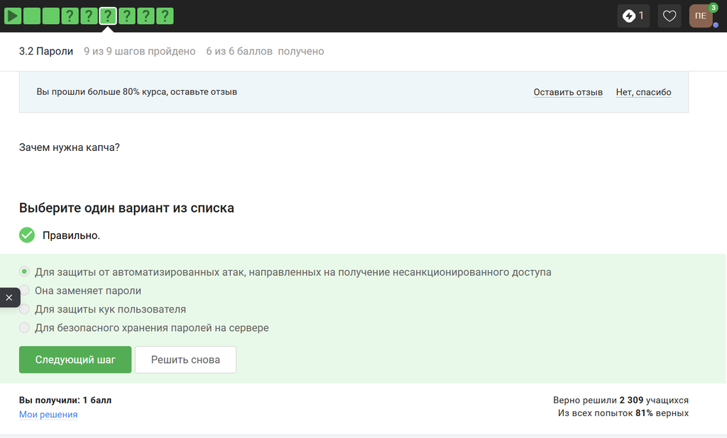

Рисунок 6: Вопрос 6

Пароли опасно хранить в открытом виде, поэтому их хранят хэши.

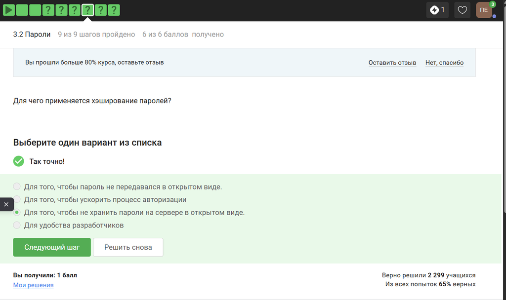

Рисунок 7: Вопрос 7

Вряд ли соль поможет.

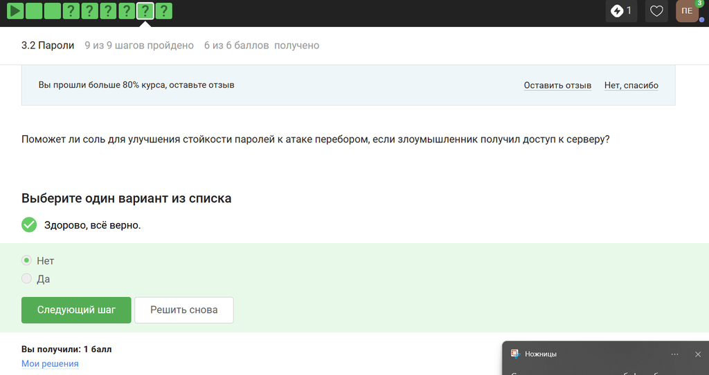

Рисунок 8: Вопрос 8

Все представленные меры защищают от утечек данных.

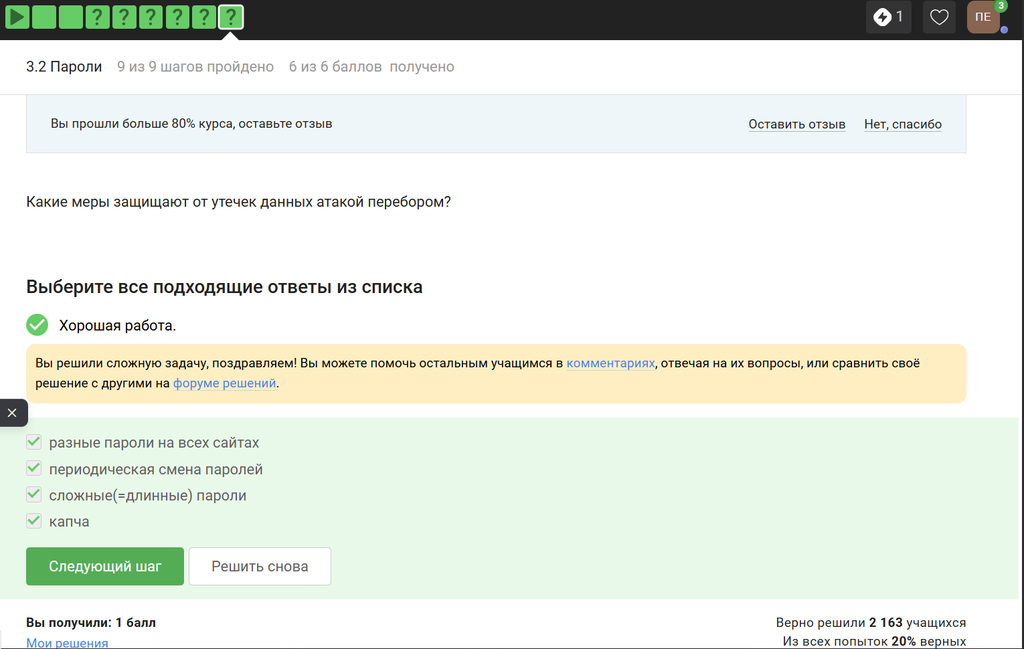

Рисунок 9: Вопрос 9

Фишинговые ссылки похожи на “оригинальные” ссылки хорошо знакомых нам сервисов, но с некоторыми отличиями.

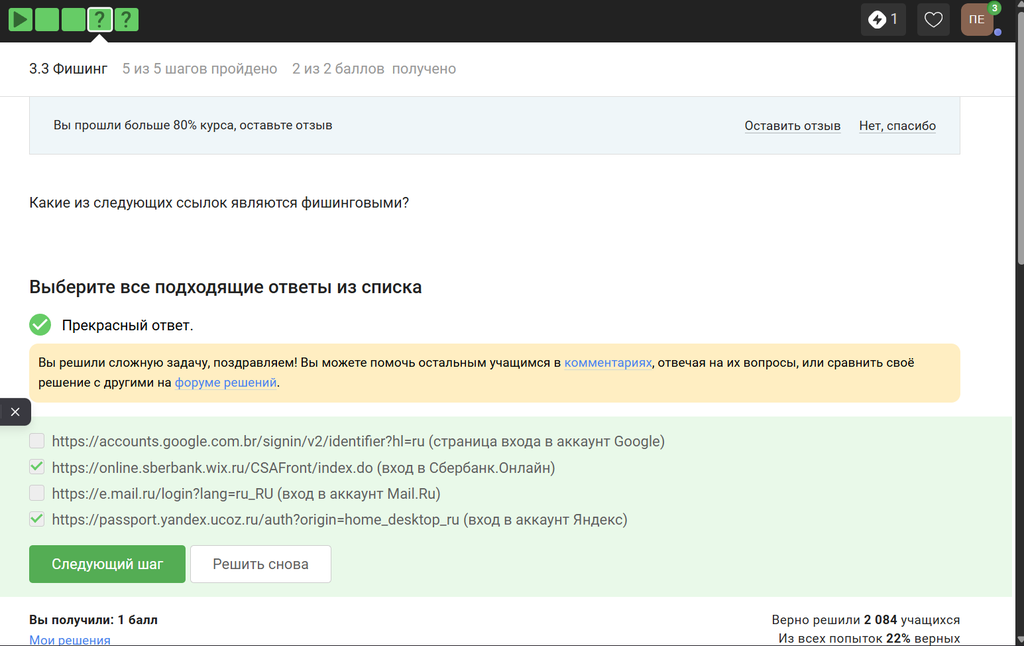

Рисунок 10: Вопрос 10

Да, может, например, если нашего знакомого взломали.

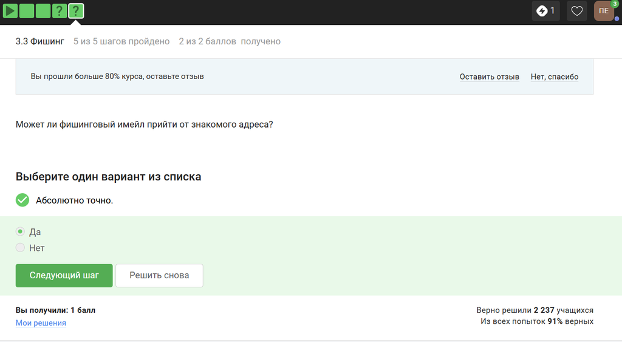

Рисунок 11: Вопрос 11

## Вирусы. Примеры

Данное определение точно описывает понятие имейл спуфинг.

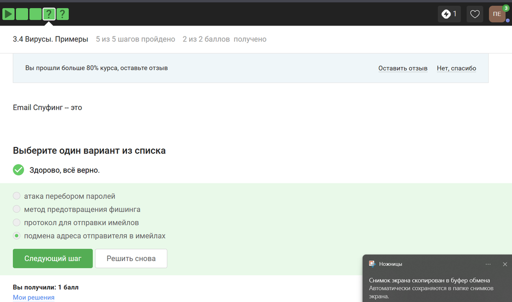

Рисунок 12: Вопрос 12

Вирусы-трояны, которые неопытный пользователь может установить по ошибке, маскируются под легитимные и полезные программы.

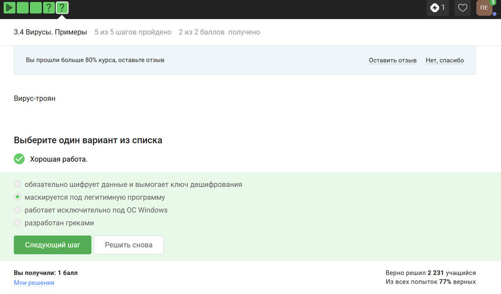

Рисунок 13: Вопрос 13

## Безопаность мессенджеров

При генерации первого сообщения отправителем формируется ключ шифрования.

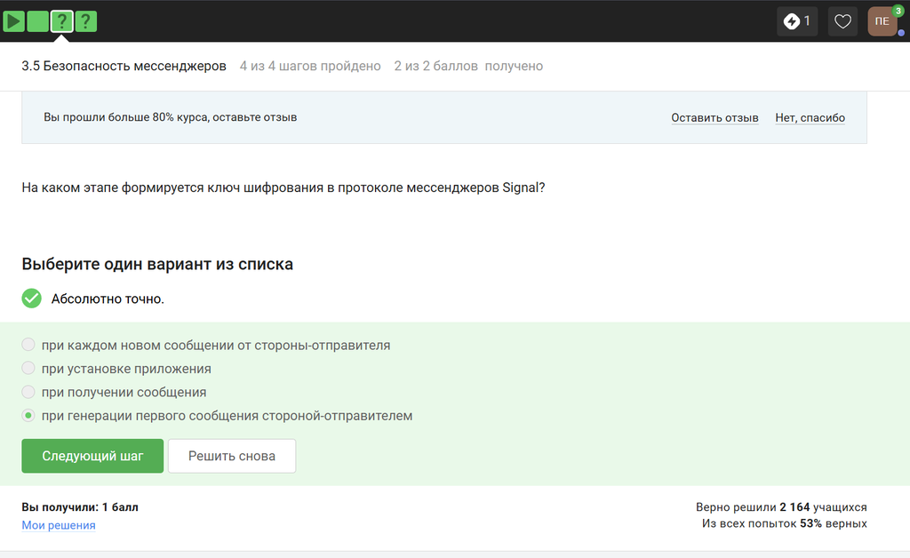

Рисунок 14: Вопрос 14

Дан исчерпывающий ответ.

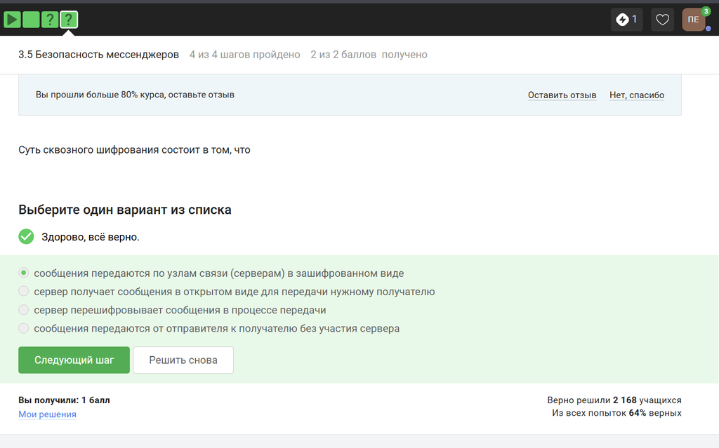

Рисунок 15: Вопрос 15

# Анализ и практическая значимость

- Изучены методы защиты устройств и данных
- Рассмотрены шифрование дисков и защита паролей
- Проанализированы фишинг и вредоносное ПО
- Получены навыки повышения пользовательской безопасности